# THC and CBD mechanisms of action

Tony Hui

April 30, 2017

## Definitions

- Agonist = something that **activates** a receptor
- Antagonist = something that **represses** a receptor
- THC = Tetrahydrocannabinol
- CBD = Cannabidiol

## Summary

### Components

Marijuana contains over 400 compounds, but the two most well studied are THC and CBD (Wikipedia, n.d.). THC binds and acts as an agonist for the endocannabinoid receptors CB1R and CB2R (Wikipedia, n.d.), while CBD binds weakly to CBR1 and 2 and instead acts through various targets such as GPR55, VDAC1, and ENT1 (Rosenberg, Patra, and Whalley 2017, Zlebnik and Cheer (2016)). The CB1 receptor is found primarily in the brain as well as in some peripheral tissues, while CB2 receptor is found in both brain and immune cells (Wikipedia, n.d.).

### Anti-depressive effects

Synthetic CB receptor agonists (CB1 and CB2) cause antidepressant-like effects in mice (as measured by immobility time) (Kruk-Slomka, Michalak, and Biala 2015). This is likely due THC-mediated increase in dopamine levels by inhibition of dopamine inhibitors (Zlebnik and Cheer 2016). Furthermore, the CB1 receptor antagonist rimonabant, while causing massive appetite inhibition and underwent clincal trial for obesity, caused severe depression and suicidal thoughts and subsequently was removed from market. Altogther, these evidence support a model where activation of CB1R by THC induces happiness and combats depression.

In addition, anxiety and stress are mitigated by CBD (Zlebnik and Cheer 2016) in humans and mice by stimulating hippocampal neurogenesis like conventional anti-depressants.

### Anti-epileptic effects

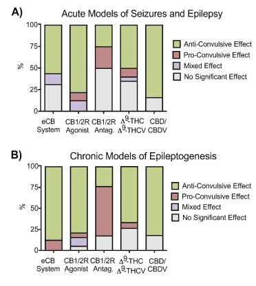

Mechanistically, activation of CB1R by THC but not CB2R is responsible for the reduction in seizures, which may be a contributor to the mixed results in the literature (Rosenberg, Patra, and Whalley 2017). On the other hand, the mechanism of CBD-conferred seizure protection is not known, but it has been discovered that CBD treatment significantly reduced neuronal loss due to hypoxic ischemic brain injury (caused by seizures) (Rosenberg, Patra, and Whalley 2017, Alvarez et al (2008)).

## References

Alvarez et al. 2008. “Neuroprotective Effects of the Nonpsychoactive Cannabinoid Cannabidiol in Hypoxic-Ischemic Newborn Piglets.” Pediatr Res. doi:10.1203/PDR.0b013e318186e5dd.

Kruk-Slomka, Michalak, and Biala. 2015. “Antidepressant-Like Effects of the Cannabinoid Receptor Ligands.” Behav Brain Res. doi:10.1016/j.bbr.2015.01.051.

Rosenberg, Patra, and Whalley. 2017. “Therapeutic Effects of Cannabinoids in Animal Models of Seizures, Epilepsy, Epileptogenesis, and Epilepsy-Related Neuroprotection.” Epilepsy Behav. doi:10.1016/j.yebeh.2016.11.006.

Wikipedia. n.d. doi:https://en.wikipedia.org/wiki/Cannabis_(drug)#Mechanism_of_action.

Zlebnik, and Cheer. 2016. “Beyond the CB1 Receptor - Is Cannabidiol the Answer for Disorders of Motivation?” Annu Rev Neurosci. doi:10.1146/annurev-neuro-070815-014038.